# **Deployment Into Production: Machine Learning API on AWS**

[figure not shown]

### Garbage Classifiation - Nhóm 8

**Thông tin nhóm**:

1. **21280048** - Bùi Quang Thắng (Nhóm Trưởng)
2. **21280052** - Lê Võ Bảo Trâm
3. **21280120** - Nguyễn Thúy Vy

### **About Project:**

- Mục đích:
  - Thứ nhất, tìm hiểu về việc triển khai một ứng dụng Machine Learning lên môi trường production (cloud platform mà chúng em sử dụng là **AWS**). Bên cạnh đó, nhóm cũng tìm hiểu những khó khăn và giải pháp về **cơ sở hạ tầng (infrastructure), hiệu năng (performance), chi phí (cost)** khi đưa model lên Cloud.
  - Thứ hai, model mà nhóm sử dụng với mục đích chính là phân loại rác. Điều này sẽ giúp giảm ô nhiễm môi trường và giúp cộng đồng nâng cao ý thức bảo vệ môi trường.
- Toàn bộ source code từ model - backend - frontend có thể truy cập nhanh thông qua repo **thangbuiq/simple_mlops**, nằm ở đường link sau:

  > https://github.com/thangbuiq/simple_mlops.git

### **Kiến trúc của software:**

[figure not shown]

### **Table of contents:**

1. Import library  
2. Data Collection  
2.1. About the dataset  
2.2. Prepare dataset  
3. Explore Data Analysis (EDA)  
4. Model  
4.1. Data Preprocessing  
4.2 Model Architecture  
4.3 Train Test Split  
4.4 Model Training and Validation  
4.5 Compare Model  
4.5.1 VGG16  
4.5.2. VGG19  
4.5.3. ResNet50  
4.5.4. ResNet152  
4.5.5. So sánh loss và accuracy trên tập test ở từng model  
4.5.6. Chọn lựa model có dung lượng/kích thước phù hợp để serving  
5. Model Serving as API  
6. Deployment On Amazon Elastic Compute Cloud (AWS EC2) with Github Actions  
7. Tự động hóa quy trình Deploy (CI/CD với Github Actions)  
8. Full Source Code: Website, Model, API

### **Import library:**

Import những thư viện cần thiết từ keras, xử lý ảnh, và validation model (confusion matrix)

```python
import warnings
warnings.filterwarnings('ignore')

!pip install -q seaborn visualkeras
import visualkeras
import numpy as np
import pandas as pd
import seaborn as sns
import matplotlib.pyplot as plt
import matplotlib.image as mpimg
import plotly.graph_objects as go
from PIL import Image
import cv2
import os

import tensorflow as tf
from keras import layers
from keras.layers import Input, Lambda, Dense, Flatten, Dropout, BatchNormalization
from keras.models import Model, load_model
from keras.optimizers import Adam
from keras.callbacks import ModelCheckpoint, EarlyStopping, ReduceLROnPlateau
from keras.applications.vgg16 import VGG16
from keras.applications.vgg19 import VGG19
from keras.applications.resnet50 import ResNet50
from keras.preprocessing import image
from keras.preprocessing.image import ImageDataGenerator
from keras.models import Sequential
from sklearn.model_selection import train_test_split
from sklearn.metrics import confusion_matrix, classification_report
```

## **Data Collection:**

### About the dataset

- Dữ liệu trong bài này được lấy và trộn từ hai dữ liệu trên Kaggle:
  - Data 6 class `[trash, glass, plastic, organic, paper, cardboard]`: https://www.kaggle.com/datasets/asdasdasasdas/garbage-classification
  - Data bổ sung gồm 12 class `[battery, biological, white-glass, brown-glass, cardboard, clothes, green-glass, metal, paper, plastic, shoes, trash]`: https://www.kaggle.com/datasets/mostafaabla/garbage-classification
- Dữ liệu 12 class từ link [Data 6 classes (link 1 bên trên)](https://www.kaggle.com/datasets/asdasdasasdas/garbage-classification) ban đầu gồm có **`[trash, glass, plastic, organic, paper, cardboard]`**. Nhưng class **`trash`** gây nhiễu cho model (dễ thấy trong class này có luôn cả túi nhựa đã xuất hiện ở class **`plastic`** và các đồ ăn đã xuất hiện ở class **`organic`**.

[figure not shown]

```python
directory_path = "/kaggle/input/d/asdasdasasdas/garbage-classification/Garbage classification/Garbage classification/trash"
image_files = sorted([file for file in os.listdir(directory_path) if file.lower().endswith(('.jpg', '.jpeg', '.png'))])[:20]
fig, axes = plt.subplots(4, 5, figsize=(15, 12))
for i, image_file in enumerate(image_files):
    img = Image.open(os.path.join(directory_path, image_file))
    ax = axes[i // 5, i % 5]
    ax.imshow(img)
    ax.axis('off')
plt.show()
```

Do đó chúng ta phải loại bỏ class này để tránh việc gây nhiễu cho model, class **`trash`** từ giờ sẽ được thay thế bằng class **`battery`** được bổ sung từ [Data 12 classes (link 2 bên trên)](https://www.kaggle.com/datasets/mostafaabla/garbage-classification)

> Data 12 class sẽ không được sử dụng chính mà chỉ dùng để bổ sung cho data 6 class, do:
> - Con số 12 class là khá nhiều cho số class cần thiết trong bài toán cần xử lý.
> - Ngoài ra, việc Data 12 class có quá nhiều class gây nhiễu như **`[green-glass, white-glass, brown-glass...]`** là không cần thiết cho bài toán và gây áp lực về hiệu năng, độ chính xác cho model.
> - Data 12 class khá mất cân bằng về số lượng giữa các class (unbalanced data).

[figure not shown]

```python
directory_path = "/kaggle/input/d/asdasdasasdas/garbage-classification/Garbage classification/Garbage classification/glass"
image_files = sorted([file for file in os.listdir(directory_path) if file.lower().endswith(('.jpg', '.jpeg', '.png'))])[:20]
fig, axes = plt.subplots(4, 5, figsize=(15, 12))
for i, image_file in enumerate(image_files):
    img = Image.open(os.path.join(directory_path, image_file))
    ax = axes[i // 5, i % 5]
    ax.imshow(img)
    ax.axis('off')
plt.show()
```

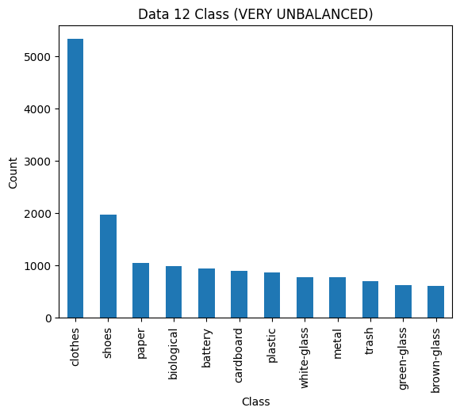

```python
root='/kaggle/input/garbage-classification/garbage_classification/'
data={}
for i in os.listdir(root):
    for j in os.walk(root+i):
        for k in j[2]:
            data[root+i+'/'+k]=i
data=pd.DataFrame(data.items(),columns=['path','class_'])
data['class_'].value_counts().plot(kind='bar')
plt.title('Data 12 Class (VERY UNBALANCED)')
plt.xlabel('Class')
plt.ylabel('Count')
plt.show()
```

- Nhóm quyết định sử dụng `white-glass` làm data chính cho class `glass` trong bộ dữ liệu mới (tránh nhầm lẫn, gây nhiễu với các class khác như metal, battery,...).

```python
data[data['class_'] == 'white-glass']['class_'].value_counts()
```

```
class_
white-glass    775
Name: count, dtype: int64
```

> Do class `white-glass` này có 775 ảnh nên nhóm sẽ dùng con số này để làm tiêu chuẩn khi mix các ảnh từ hai tập dữ liệu để data balance hơn.

### Prepare dataset:

> Nhóm đã lọc lại một số class (label lại data) và upload dataset này lên kaggle.
- Link dataset: https://www.kaggle.com/datasets/quangtheng/garbage-classification-6-classes-775class

Data mới gồm 6 class **[metal, glass, organic, paper, battery, plastic]**, trong đó:

- Nhóm chọn con số 775 vì đây là kích thước tối đa có thể bổ sung được từ cả 2 dataset để kích thước mỗi class là bằng nhau.
- 3 class **[metal, paper, plastic]** từ base data ([data 6 class gốc](https://www.kaggle.com/datasets/asdasdasasdas/garbage-classification)), nếu kích thước class nào chưa đủ 775, sẽ lấy từ ([data 12 class](https://www.kaggle.com/datasets/mostafaabla/garbage-classification)) để bổ sung và fill up 775 ảnh.
- 3 class **[glass, battery, organic]** được thu thập hoàn toàn từ một dataset là ([data 12 class](https://www.kaggle.com/datasets/mostafaabla/garbage-classification)), trong đó class **organic** được đổi tên từ **biological**, class **glass** được đổi tên từ **white-glass**.

**Code bổ sung và relabeling data:**

```python
import os
import shutil

original_path = '/kaggle/input/d/asdasdasasdas/garbage-classification/Garbage classification/Garbage classification/'
bonus_data_path = '/kaggle/input/garbage-classification/garbage_classification/'
destination_path = '/kaggle/working/modified_dataset/'

if os.path.exists(destination_path) and os.path.isdir(destination_path):
    shutil.rmtree(destination_path)

os.makedirs(destination_path, exist_ok=True)
classes_to_remove = ['cardboard', 'trash', 'glass'] # in original data
new_classes = ['battery', 'biological', 'white-glass'] # in bonus data
target_image_count = 775

for class_name in os.listdir(original_path):
    class_path = os.path.join(original_path, class_name)

    if class_name in classes_to_remove:
        continue

    new_class_name = class_name
    if class_name in new_classes:
        new_class_name = new_classes[new_classes.index(class_name)]

    new_class_path = os.path.join(destination_path, new_class_name)
    os.makedirs(new_class_path, exist_ok=True)
    files_to_copy = os.listdir(class_path)[:target_image_count]
    for file_name in files_to_copy:
        file_path = os.path.join(class_path, file_name)
        shutil.copy(file_path, new_class_path)

    # If the class has fewer than target_image_count images, fill up from bonus data
    if len(os.listdir(new_class_path)) < target_image_count:
        remaining_images = target_image_count - len(os.listdir(new_class_path))
        print(f"{class_name} has {len(os.listdir(new_class_path))} images and missing {remaining_images} to fill {target_image_count}.")
        if class_name == "glass":
            bonus_class_path = os.path.join(bonus_data_path, "white-glass")
        else:
            bonus_class_path = os.path.join(bonus_data_path, class_name)
        if bonus_class_path:
            bonus_files = os.listdir(bonus_class_path)
            copied_names = set(os.listdir(new_class_path))
            for file_name in bonus_files:
                if remaining_images == 0:
                    break
                new_file_name = file_name
                counter = 1
                while new_file_name in copied_names:
                    base_name, extension = os.path.splitext(file_name)
                    new_file_name = f"{class_name}_{counter}{extension}"
                    counter += 1
                file_path = os.path.join(bonus_class_path, file_name)
                new_file_path = os.path.join(new_class_path, new_file_name)
                shutil.copy(file_path, new_file_path)
                copied_names.add(new_file_name)
                remaining_images -= 1

# Process the bonus dataset to copy battery and organic data
for class_name in os.listdir(bonus_data_path):
    class_path = os.path.join(bonus_data_path, class_name)
    if class_name in new_classes:
        new_class_name = class_name
        if class_name in new_classes:
            new_class_name = new_classes[new_classes.index(class_name)]
        if new_class_name == "biological":
            new_class_path = os.path.join(destination_path, "organic")
        elif new_class_name == "white-glass":
            new_class_path = os.path.join(destination_path, "glass")
        else:
            new_class_path = os.path.join(destination_path, new_class_name)
        os.makedirs(new_class_path, exist_ok=True)
        files_to_copy = os.listdir(class_path)[:target_image_count]
        for file_name in files_to_copy:
            file_path = os.path.join(class_path, file_name)
            shutil.copy(file_path, new_class_path)

print("\nFINISH: Dataset modification complete.")
for class_ in os.listdir(destination_path):
    count_class = len(os.listdir(os.path.join(destination_path, class_)))
    print(f"{class_} has {count_class} images.")
```

```
metal has 410 images and missing 365 to fill 775.
paper has 594 images and missing 181 to fill 775.
plastic has 482 images and missing 293 to fill 775.

FINISH: Dataset modification complete.
battery has 775 images.
glass has 775 images.
paper has 775 images.
metal has 775 images.
plastic has 775 images.
organic has 775 images.
```

## **Explore Data Analysis (EDA):**

- Trước hết, chúng ta sẽ bắt đầu khám phá dữ liệu để có cái nhìn tổng quan và hiểu rõ về cấu trúc và tính chất của tập dữ liệu. Qua đó, chúng ta sẽ có cơ sở để tiếp tục thực hiện các bước tiếp theo để giải quyết bài toán đặt ra.

```python
data_path = '/kaggle/input/garbage-classification-6-classes-775class/'
data_classes = os.listdir(data_path)
data_classes
```

```
['metal', 'glass', 'organic', 'paper', 'battery', 'plastic']
```

- Trong dataset mới này, các hình ảnh sẽ thuộc các nhóm chính bao gồm: `metal`, `glass`, `organic`, `paper`, `battery`, và `plastic`.

```python
for class_ in os.listdir(data_path):
    count_class = 0
    for photo in os.listdir(data_path + class_):
        count_class += 1
    print(str(class_) + " has " + str(count_class) + " images.")
```

```
metal has 775 images.
glass has 775 images.
organic has 775 images.
paper has 775 images.
battery has 775 images.
plastic has 775 images.
```

- Lúc này dataset gồm 6 classes dữ liệu đều có 775 ảnh.
- Để thuận tiện cho việc phân tích, chúng ta sẽ tạo một dataframe gồm có:
  - `path`: đường dẫn đến ảnh.
  - `type_trash`: loại rác của ảnh.

```python
data = pd.DataFrame()
for class_ in os.listdir(data_path):
    temp = pd.DataFrame()
    temp['path'] = np.nan
    temp['type_trash'] = class_
    i = 0
    for photo in os.listdir(data_path + class_):
        temp.loc[i, 'path'] = data_path + class_ + "/" + photo
        temp.loc[i, 'type_trash'] = class_
        i += 1
    data = pd.concat([data, temp], ignore_index=True)
    del temp
data.shape
```

```
(4650, 2)
```

> Dataframe sẽ gồm có 4650 dòng (tức 4650 ảnh) và 2 cột

```python
data = data.sample(frac=1)
data.reset_index(drop=True, inplace=True)
data.head(3)
```

|  | path | type_trash |
| --- | --- | --- |
| 0 | /kaggle/input/garbage-classification-6-classes... | plastic |
| 1 | /kaggle/input/garbage-classification-6-classes... | glass |
| 2 | /kaggle/input/garbage-classification-6-classes... | plastic |

- In ra một hình ảnh bất kỳ từ dataset:

[figure not shown]

```python
def display_images_with_labels(df, idx):
        row = df.iloc[idx]
        image_path = row['path']
        image_label = row['type_trash']
        img = mpimg.imread(image_path)
        plt.imshow(img)
        plt.title(f'Label: {image_label}')
        plt.axis('off')
        plt.show()

display_images_with_labels(data, 1040)
```

## **Model:**

- Đầu tiên, nhóm có preprocessing và sử dụng CNN thuần để train model. Kết quả nhận được là accuracy khoảng ~80%. Khi đưa model CNN này lên môi trường production thì hầu như test đều cho kết quả sai. Do đó, nhóm đã tìm hiểu và tham khảo một số paper có nghiên cứu về chủ đề liên quan thì họ sẽ sử dụng những kiến trúc mới và tốt hơn để xử lý ảnh như: VGG16, ResNet,...
- Vì vậy, nhóm sẽ sử dụng một số model nổi tiếng về phân loại ảnh để tiền xử lý và train model.
- Sau khi train và có kết quả, nhóm sẽ so sánh loss và accuracy từng model để chọn ra model phù hợp nhất cho việc serving và triển khai API.

### **Data Preprocessing:**

- Để sử dụng mô hình này, trước hết ta phải thực hiện các bước tiền xử lý hình ảnh đúng chuẩn yêu cầu của VGG16.
- Hàm `image_preprocessing`:
  - **Input:** img_path (đường dẫn đến link ảnh)
  - **Output:** img (hình ảnh đã qua xử lý)

```python
from keras.applications.vgg16 import preprocess_input

def image_preprocessing(img_path):
    img = image.load_img(img_path, target_size=(224, 224))
    img = image.img_to_array(img)
    img = np.expand_dims(img, axis=0)
    img = preprocess_input(img)
    return img
```

Các bước thực hiện quá trình trên gồm có:

- Đọc hình ảnh từ link ảnh `img_path` với kích thước chuẩn là `(224,224)` (VGG16 yêu cầu kích thước đầu vào của ảnh là 224x224).
- Chuyển hình ảnh đã đọc thành một mảng. Mảng này sẽ chứa thông tin về pixel của hình ảnh. Kích thước là `(224, 224, 3)`; trong đó 3 tức là 3 kênh màu RGB.
- Mở rộng kích thước ảnh thêm 1 chiều -> lúc này ảnh sẽ có kích thước là `(1, 224, 224, 3)` -> `tensor`.
- Cuối cùng, ta sử dụng `preprocess_input` để chuyển đổi hình ảnh đầu vào từ RGB sang BGR, sau đó lấy trung bình mỗi kênh màu.

[figure not shown]

```python
def plot_images(original, preprocessed):
    fig, axs = plt.subplots(1, 2, figsize=(10, 5))
    axs[0].imshow(original)
    axs[0].set_title('Original Image')
    axs[0].axis('off')
    axs[1].imshow(np.squeeze(preprocessed, axis=0))
    axs[1].set_title('Preprocessed Image')
    axs[1].axis('off')
    plt.show()

img_path = '/kaggle/input/garbage-classification-6-classes-775class/plastic/plastic125.jpg'
original_image = Image.open(img_path)
preprocessed_image = image_preprocessing(img_path)
plot_images(original_image, preprocessed_image)
```

- Như kết quả trên, hình ảnh sau khi tiền xử lý sẽ có kích thước 224x224. Background ảnh sẽ chuyển về màu trắng và các màu sắc của đối tượng trong hình cũng sẽ thay đổi. *Việc thực hiện quá trình trên sẽ làm cho tất cả các ảnh trong dataset về cùng định dạng kích thước. Bên cạnh đó, data khi train sẽ cho kết quả tốt hơn.

#### Model Architecture:

```
Downloading data from https://storage.googleapis.com/tensorflow/keras-applications/vgg16/vgg16_weights_tf_dim_ordering_tf_kernels_notop.h5
```

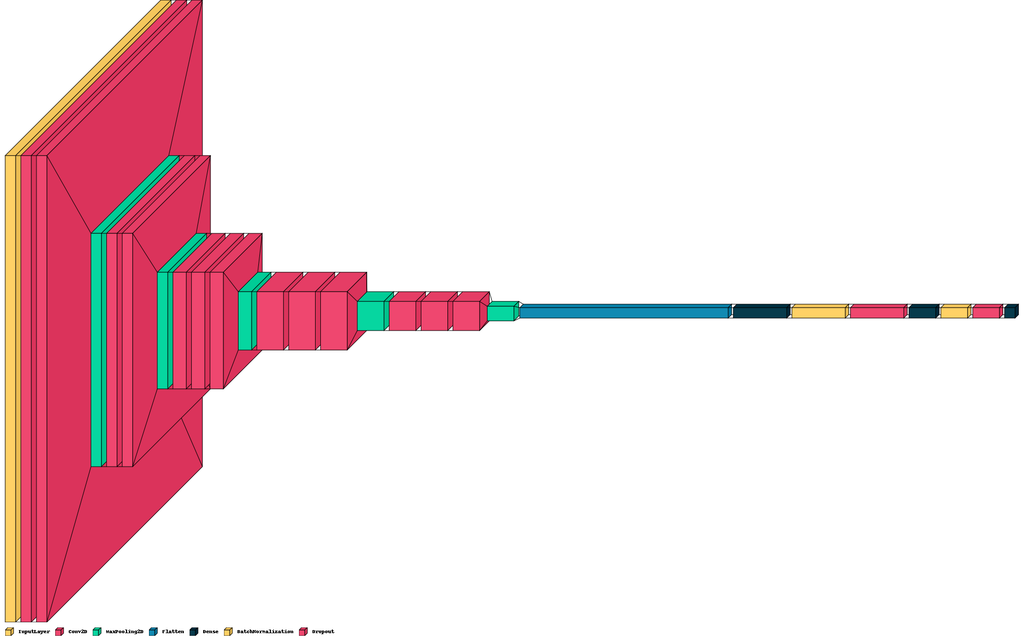

```python
BATCH_SIZE = 64
n_classes = 6

# VGG16 base model
conv_base = VGG16(
    include_top=False,
    weights='imagenet',
    input_shape=(224, 224, 3)
)

# Freeze all layers except the last two
for layer in conv_base.layers[:-2]:
    layer.trainable = False

# Fine-tune model
top_model = conv_base.output
top_model = Flatten(name="flatten")(top_model)
top_model = Dense(1024, activation='relu')(top_model)  # Increased units
top_model = BatchNormalization()(top_model)
top_model = Dropout(0.5)(top_model)
top_model = Dense(512, activation='relu')(top_model)  # Increased units
top_model = BatchNormalization()(top_model)
top_model = Dropout(0.5)(top_model)
output_layer = Dense(n_classes, activation='softmax')(top_model)

# Final Model
model = Model(inputs=conv_base.input, outputs=output_layer)
visualkeras.layered_view(model, to_file='model_architecture.png', legend=True)
```

```python
model.summary()
```

```
Model: "model"
_________________________________________________________________
 Layer (type)                Output Shape              Param #
=================================================================
 input_1 (InputLayer)        [(None, 224, 224, 3)]     0

 block1_conv1 (Conv2D)       (None, 224, 224, 64)      1792

 block1_conv2 (Conv2D)       (None, 224, 224, 64)      36928

 block1_pool (MaxPooling2D)  (None, 112, 112, 64)      0

 block2_conv1 (Conv2D)       (None, 112, 112, 128)     73856

 block2_conv2 (Conv2D)       (None, 112, 112, 128)     147584

 block2_pool (MaxPooling2D)  (None, 56, 56, 128)       0

 block3_conv1 (Conv2D)       (None, 56, 56, 256)       295168

 block3_conv2 (Conv2D)       (None, 56, 56, 256)       590080

 block3_conv3 (Conv2D)       (None, 56, 56, 256)       590080

 block3_pool (MaxPooling2D)  (None, 28, 28, 256)       0

 block4_conv1 (Conv2D)       (None, 28, 28, 512)       1180160

 block4_conv2 (Conv2D)       (None, 28, 28, 512)       2359808

 block4_conv3 (Conv2D)       (None, 28, 28, 512)       2359808

 block4_pool (MaxPooling2D)  (None, 14, 14, 512)       0

 block5_conv1 (Conv2D)       (None, 14, 14, 512)       2359808

 block5_conv2 (Conv2D)       (None, 14, 14, 512)       2359808

 block5_conv3 (Conv2D)       (None, 14, 14, 512)       2359808

```

[output cut: 10 more lines]

```

 dense_1 (Dense)             (None, 512)               524800

 batch_normalization_1 (Bat  (None, 512)               2048
 chNormalization)

 dropout_1 (Dropout)         (None, 512)               0

 dense_2 (Dense)             (None, 6)                 3078

=================================================================
Total params: 40939846 (156.17 MB)
Trainable params: 28581894 (109.03 MB)
Non-trainable params: 12357952 (47.14 MB)
_________________________________________________________________
```

- In ra 20 ảnh ngẫu nhiên từ 1 batch:

```python
def plot_random_images(generator, num_images=20):
    # Get a batch of data from the generator
    images, labels = next(generator)
    random_indices = np.random.choice(images.shape[0], num_images, replace=False)

    fig, axs = plt.subplots(4, 5, figsize=(15, 12))
    fig.suptitle('Random 20 Images from the Generator', fontsize=16)

    for i, ax in enumerate(axs.flatten()):
        index = random_indices[i]
        image = images[index]
        label = labels[index]
        ax.imshow(image)
        ax.set_title(f'Class: {np.argmax(label)}')
        ax.axis('off')

    plt.show()
```

```
Found 4650 images belonging to 6 classes.
```

[figure not shown]

```python
gen_train = ImageDataGenerator(preprocessing_function=preprocess_input) # VGG16 preprocessing
full_data = gen_train.flow_from_directory(data_path, target_size = (224, 224), batch_size = BATCH_SIZE, class_mode="categorical")
plot_random_images(full_data)
```

#### Train Test Split:

- Trước khi train model, chúng ta chia data thành tập train và test. Ở đây, nhóm sẽ tách theo tỉ lệ: 90% cho tập train, 10% cho tập test.

```python
filenames = full_data.filenames
labels = full_data.labels
class_mapping = {value: str(key) for key, value in full_data.class_indices.items()}
labels = [class_mapping[label] for label in labels]

# Split the data into training and testing sets
train_filenames, test_filenames, train_labels, test_labels = train_test_split(filenames, labels, test_size=0.1, random_state=42)

train_df = pd.DataFrame({'filename': train_filenames, 'class': train_labels})
test_df = pd.DataFrame({'filename': test_filenames, 'class': test_labels})

# Create separate generators for training and testing using flow_from_dataframe
train_data = gen_train.flow_from_dataframe(train_df, directory=data_path, target_size=(224, 224),
                                           batch_size=BATCH_SIZE, class_mode="categorical",
                                           shuffle=True, seed=42)

test_data = gen_train.flow_from_dataframe(test_df, directory=data_path, target_size=(224, 224),
                                          batch_size=BATCH_SIZE, class_mode="categorical",
                                          shuffle=False)
```

```
Found 4185 validated image filenames belonging to 6 classes.
Found 465 validated image filenames belonging to 6 classes.
```

### Model Training and Validation

Trong quá trình train model, nhóm có sử dụng một số kỹ thuật như sau:

- **Checkpoint:** chỉ lưu lại trạng thái tốt nhất của model (có validation loss thấp nhất).
- **Early Stopping:** dừng nếu model không cải thiện sau một số epoch nhất định (được định nghĩa theo thông số patience, chúng em set ở đây là 15 epoch, sau 15 epoch mà model không cải thiện, quá trình train sẽ dừng để tránh tốn resource)
- **Reduce Learning Rate:** Giảm learning rate để tránh overfit

Nhóm sẽ sử dụng 4 kiến trúc khác nhau để train model. Do việc train model tốn thời gian nên dưới đây là link train từng model mà nhóm đã làm rồi up lại lên kaggle.

- VGG16: https://www.kaggle.com/code/quangtheng/94-acc-vgg16-fine-tune

Để sử dụng từng model trên, nhóm chỉ cần save model thành các file `.h5` rồi load lên sử dụng.

```python
vgg16 = load_model("/kaggle/input/garbage-classifier-model/garbage_classifier.vgg_16.h5")
```

```python
output_class = ["battery", "glass", "metal","organic", "paper", "plastic"]

def preprocessing_input(img_path):
    img = image.load_img(img_path, target_size=(224, 224))
    img = image.img_to_array(img)
    img = np.expand_dims(img, axis=0)
    img = preprocess_input(img) # VGG16 preprocess_input
    return img

def plot_images(original, preprocessed):
    fig, axs = plt.subplots(1, 2, figsize=(10, 5))

    axs[0].imshow(original)
    axs[0].set_title('Original Image')
    axs[0].axis('off')

    # Remove the batch dimension for display
    preprocessed = np.squeeze(preprocessed, axis=0)

    axs[1].imshow(preprocessed)
    axs[1].set_title('Preprocessed Image')
    axs[1].axis('off')

    plt.show()

def predict_user(img_path):
    img = preprocessing_input(img_path)
    plot_images(Image.open(img_path), img)
    predicted_array = model.predict(img)
    predicted_value = output_class[np.argmax(predicted_array)]
    predicted_accuracy = round(np.max(predicted_array) * 100, 2)
    print("Your waste material is", predicted_value, "with", predicted_accuracy, "% accuracy.")
```

### **Compare Model:**

- Làm tương tự các bước ở trên cho VGG19, ResNet50 và Resnet152. Link notebook mà nhóm đã xử lý và train:
  - VGG19: https://www.kaggle.com/code/tramlevobao/vgg19
  - ResNet50: https://www.kaggle.com/code/tramlevobao/resnet50
  - ResNet152: https://www.kaggle.com/code/tramlevobao/resnet152
- Mỗi model ở trên sẽ được lưu lại và load lên để sử dụng. Để chọn ra model nào là tốt nhất cho việc triển khai lên môi trường production, chúng ta sẽ so sánh loss, accuracy qua từng confusion matrix.

#### **VGG16**:

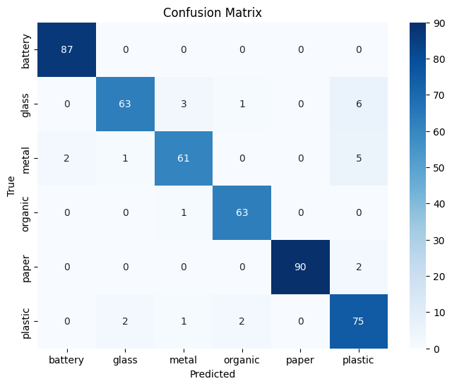

```
              precision    recall  f1-score   support

     battery       0.98      1.00      0.99        87
       glass       0.95      0.86      0.91        73
       metal       0.92      0.88      0.90        69
     organic       0.95      0.98      0.97        64
       paper       1.00      0.98      0.99        92
     plastic       0.85      0.94      0.89        80

    accuracy                           0.94       465
   macro avg       0.94      0.94      0.94       465
weighted avg       0.95      0.94      0.94       465
```

```python
predictions = vgg16.predict(test_data)

# Get the predicted class labels
predicted_labels = np.argmax(predictions, axis=1)

# Get the true class labels
true_labels = test_data.classes

# Compute confusion matrix
conf_matrix = confusion_matrix(true_labels, predicted_labels)

# Plot confusion matrix using seaborn
plt.figure(figsize=(8, 6))
sns.heatmap(conf_matrix, annot=True, fmt='d', cmap='Blues',
            xticklabels=test_data.class_indices.keys(),
            yticklabels=test_data.class_indices.keys())
plt.xlabel('Predicted')
plt.ylabel('True')
plt.title('Confusion Matrix')
plt.show()

# Print classification report
class_names = list(test_data.class_indices.keys())
print(classification_report(true_labels, predicted_labels, target_names=class_names))
```

#### **VGG19**:

```python
vgg19 = load_model("/kaggle/input/garbage-classifier-model/garbage_classifier.vgg_19.h5")
```

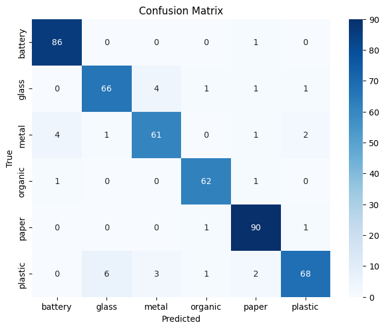

```
              precision    recall  f1-score   support

     battery       0.95      0.99      0.97        87
       glass       0.90      0.90      0.90        73
       metal       0.90      0.88      0.89        69
     organic       0.95      0.97      0.96        64
       paper       0.94      0.98      0.96        92
     plastic       0.94      0.85      0.89        80

    accuracy                           0.93       465
   macro avg       0.93      0.93      0.93       465
weighted avg       0.93      0.93      0.93       465
```

```python
predictions = vgg19.predict(test_data)

# Get the predicted class labels
predicted_labels = np.argmax(predictions, axis=1)

# Get the true class labels
true_labels = test_data.classes

# Compute confusion matrix
conf_matrix = confusion_matrix(true_labels, predicted_labels)

# Plot confusion matrix using seaborn
plt.figure(figsize=(8, 6))
sns.heatmap(conf_matrix, annot=True, fmt='d', cmap='Blues',
            xticklabels=test_data.class_indices.keys(),
            yticklabels=test_data.class_indices.keys())
plt.xlabel('Predicted')
plt.ylabel('True')
plt.title('Confusion Matrix')
plt.show()

# Print classification report
class_names = list(test_data.class_indices.keys())
print(classification_report(true_labels, predicted_labels, target_names=class_names))
```

#### **ResNet50**:

```python
resnet50 = load_model("/kaggle/input/garbage-classifier-model/garbage_classifier.resnet50.h5")
```

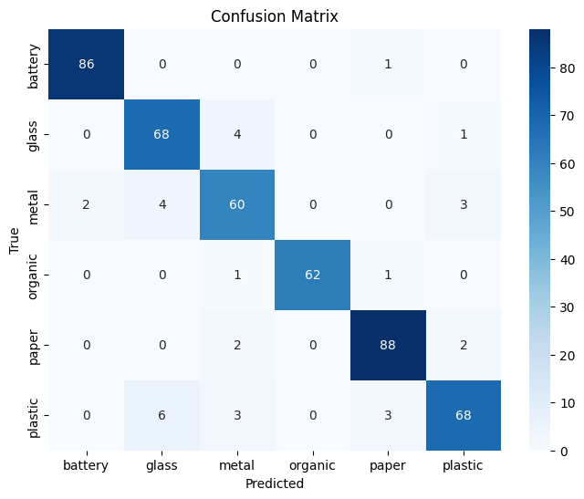

```
              precision    recall  f1-score   support

     battery       0.98      0.99      0.98        87
       glass       0.87      0.93      0.90        73
       metal       0.86      0.87      0.86        69
     organic       1.00      0.97      0.98        64
       paper       0.95      0.96      0.95        92
     plastic       0.92      0.85      0.88        80

    accuracy                           0.93       465
   macro avg       0.93      0.93      0.93       465
weighted avg       0.93      0.93      0.93       465
```

```python
predictions = resnet50.predict(test_data)

# Get the predicted class labels
predicted_labels = np.argmax(predictions, axis=1)

# Get the true class labels
true_labels = test_data.classes

# Compute confusion matrix
conf_matrix = confusion_matrix(true_labels, predicted_labels)

# Plot confusion matrix using seaborn
plt.figure(figsize=(8, 6))
sns.heatmap(conf_matrix, annot=True, fmt='d', cmap='Blues',
            xticklabels=test_data.class_indices.keys(),
            yticklabels=test_data.class_indices.keys())
plt.xlabel('Predicted')
plt.ylabel('True')
plt.title('Confusion Matrix')
plt.show()

# Print classification report
class_names = list(test_data.class_indices.keys())
print(classification_report(true_labels, predicted_labels, target_names=class_names))
```

#### **ResNet152**:

```python
resnet152 = load_model("/kaggle/input/garbage-classifier-model/garbage_classifier.resnet152.h5")
```

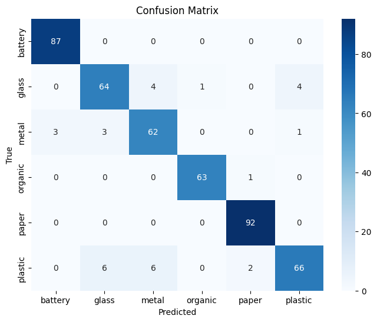

```
              precision    recall  f1-score   support

     battery       0.97      1.00      0.98        87
       glass       0.88      0.88      0.88        73
       metal       0.86      0.90      0.88        69
     organic       0.98      0.98      0.98        64
       paper       0.97      1.00      0.98        92
     plastic       0.93      0.82      0.87        80

    accuracy                           0.93       465
   macro avg       0.93      0.93      0.93       465
weighted avg       0.93      0.93      0.93       465
```

```python
predictions = resnet152.predict(test_data)

# Get the predicted class labels
predicted_labels = np.argmax(predictions, axis=1)

# Get the true class labels
true_labels = test_data.classes

# Compute confusion matrix
conf_matrix = confusion_matrix(true_labels, predicted_labels)

# Plot confusion matrix using seaborn
plt.figure(figsize=(8, 6))
sns.heatmap(conf_matrix, annot=True, fmt='d', cmap='Blues',
            xticklabels=test_data.class_indices.keys(),
            yticklabels=test_data.class_indices.keys())
plt.xlabel('Predicted')
plt.ylabel('True')
plt.title('Confusion Matrix')
plt.show()

# Print classification report
class_names = list(test_data.class_indices.keys())
print(classification_report(true_labels, predicted_labels, target_names=class_names))
```

#### So sánh loss và accuracy trên tập test ở từng model

Cuối cùng, để có thể quyết định chọn model nào là ổn định và tốt nhất cho việc serving API, ta so sánh loss và accuracy của từng model.

```python
models = [vgg16, vgg19, resnet50, resnet152]
model_names = ['VGG16', 'VGG19', 'ResNet50', 'ResNet152']

loss_values = []
accuracy_values = []
# Evaluate and store loss/accuracy for each model
for model, name in zip(models, model_names):
    loss, accuracy = model.evaluate_generator(test_data)
    loss_values.append(loss)
    accuracy_values.append(accuracy)
```

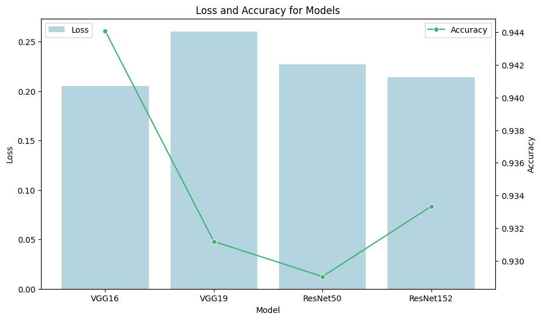

```python
loss_color = 'lightblue'
accuracy_color = 'mediumseagreen'
fig, ax1 = plt.subplots(figsize=(10, 6))
sns.barplot(x=model_names, y=loss_values, color=loss_color, ax=ax1, label='Loss')
ax2 = ax1.twinx()
sns.lineplot(x=model_names, y=accuracy_values, color=accuracy_color, marker='o', ax=ax2, label='Accuracy')
ax1.set_xlabel('Model')
ax1.set_ylabel('Loss', color='black')
ax2.set_ylabel('Accuracy', color='black')
plt.title('Loss and Accuracy for Models')
ax1.legend(loc='upper left')
ax2.legend(loc='upper right')
plt.show()
```

Như kết quả trển, thứ tự loss và accuracy tốt nhất lần lượt là:

- Loss: VGG16 - ResNet152 - ResNet50 - VGG19
- Accuracy: VGG16 > ResNet152 > VGG19 > ResNet50

#### Chọn lựa model có dung lượng/kích thước phù hợp để serving

Để xem và so sánh kích thước của các model, ta viết hàm lấy kích thước dựa theo link từng file:

- *Input*: file_path
- *Output*: size

```python
def get_file_size(file_path):
    if os.path.exists(file_path):
        # Lấy kích thước của file và chuyển đổi thành đơn vị MB
        size_in_bytes = os.path.getsize(file_path)
        size_in_mb = size_in_bytes / (1024 * 1024)  # 1 MB = 1024 KB = 1024 * 1024 bytes
        return size_in_mb
```

```python
size_vgg16 = get_file_size('/kaggle/input/garbage-classifier-model/garbage_classifier.vgg_16.h5')
size_vgg19 = get_file_size('/kaggle/input/garbage-classifier-model/garbage_classifier.vgg_19.h5')
size_resnet50 = get_file_size('/kaggle/input/garbage-classifier-model/garbage_classifier.resnet50.h5')
size_resnet152 = get_file_size('/kaggle/input/model-resnet/model_resnet152.h5')
```

```python
# Đường dẫn đến các file .h5
file_paths = [
    '/kaggle/input/garbage-classifier-model/garbage_classifier.vgg_16.h5',
    '/kaggle/input/garbage-classifier-model/garbage_classifier.vgg_19.h5',
    '/kaggle/input/garbage-classifier-model/garbage_classifier.resnet50.h5',
    '/kaggle/input/garbage-classifier-model/garbage_classifier.resnet152.h5'
]

# Kích thước của các file
file_sizes = [get_file_size(file_path) for file_path in file_paths]

# Tên của các mô hình
model_names = ['VGG16', 'VGG19', 'ResNet50', 'ResNet152']
for model, size in zip(model_names, file_sizes):
    print(f"Size (MB) of model {model}: {size:.2f} MB")
```

```
Size (MB) of model VGG16: 374.35 MB
Size (MB) of model VGG19: 100.56 MB
Size (MB) of model ResNet50: 97.39 MB
Size (MB) of model ResNet152: 231.06 MB
```

## **Model Serving as API:**

- Cuối cùng, để có thể đưa model đã thực hiện lên web thành sản phẩm cho người dùng sử dụng, chúng ta tiến hành viết API để serving model.
- Python API framework mà chúng em sử dụng là FastAPI. Lý do sử dụng là vì FastAPI là một micro framework khá mới, cho hiệu suất cao, đơn giản và dễ viết. Bên cạnh đó, FastAPI còn hỗ trợ `/docs` để dễ dàng kiểm tra và sử dụng.
- Link github: https://github.com/thangbuiq/simple_mlops/blob/main/backend/main.py

  > Các hàm sử dụng cho các route được định nghĩa ở file utils.py sau: https://github.com/thangbuiq/simple_mlops/blob/main/backend/utils.py
- Giải thích chi tiết:
  - Đầu tiên import các thư viện và modules cần thiết.
  - Khởi tạo các biến môi trường: Sử dụng os.environ.get để lấy giá trị của các biến môi trường PUBLIC_IP_ADDRESS và PUBLIC_DNS_ADDRESS, sau đó định nghĩa danh sách địa chỉ origins để xác định các nguồn được phép truy cập API.
  - Khởi tạo API `app = FastAPI` gồm tên và mô tả tương ứng
  - `app.add_middleware`: cho phép yêu cầu từ list nguồn origins ở trước.
  - Định nghĩa Base Model `trash`: Sử dụng Pydantic để định nghĩa một json-schema có tên là "trash" với một trường là "type_trash" kiểu dữ liệu là string (bắt buộc người dùng API phải theo format này).

[figure not shown]

- Các endpoint của API:
  - Các endpoint `upload` và `download` dùng để debug/test.
  - **`@app.get("/")`**:
    - Method: GET.
    - Mục đích: Trả về thông điệp chào và hướng dẫn sử dụng API.
    - Output: Một JSON object chứa lời giới thiệu và hướng dẫn.

[figure not shown]

  - **`@app.post("/predict")`**:
    - Method: POST.
    - Mục đích: nhận và xử lý một file hình từ server, sau đó dự đoán phân loại và độ chính xác.
    - Input: file hình.
    - Output: đường dẫn của file, giá trị dự đoán và độ chính xác được dự đoán.

[figure not shown]

  - **`@app.post("/get-advice")`**:
    - Method: POST.
    - Mục đích: nhận thông tin về loại rác, sau đó đưa ra lời khuyên xử lí rác và tốc độ xử lý.
    - Input: Loại rác.
    - Output: lời khuyên xử lý, thời gian.

[figure not shown]

- Sử dụng `uvicorn.run` để chạy ứng dụng FastAPI với cài đặt host là "0.0.0.0" và port là 8000.

[figure not shown]

### **Deployment On Amazon Elastic Compute Cloud (AWS EC2) with Github Actions**

Để làm một ví dụ minh họa cho API (call và sử dụng API mà chúng em đã implement), chúng em viết một app React đơn giản gồm các chức năng chính như: upload ảnh, mở camera chụp ảnh, drag and drop ảnh và paste ảnh,... -> Tất cả những thao tác này sẽ gửi ảnh vào trong một **formData** đến lần lượt là route **/predict**, và sau đó là **/get-advice** ở API host trên cùng một nơi với app frontend (port 8000).

Bây giờ, ta nhìn qua lại kiến trúc software được sử dụng để deploy:

[figure not shown]

Để một app chạy thành công trên server, trước tiên ta phải chạy nó thành công ở máy local. Để giảm tải việc setup quá nhiều thứ trên server, ta sẽ **containerize** toàn bộ app của chúng ta lại thành một docker image có tên **`proenv_app`** (kích thước image là **1.49GB**). Cuối cùng khi deploy, ta chỉ cần lên server và cài mỗi **Docker**.

[figure not shown]

Trước tiên, ta cần tạo một máy EC2 trên AWS. Tụi em sử dụng chính account cá nhân của mình và bắt đầu lựa chọn instance với chi phí phù hợp.

[figure not shown]

> Ở đây, nhóm đã thử qua các instance type có free-tier lần lượt là "t2.nano", "t2.micro", "t3.micro" và nhận thấy được hiệu năng của hai cấu hình máy này không thể đáp ứng nổi việc host hay deploy một model Keras. Do đó nhóm đã chọn một lựa chọn có phần tốn kém hơn chút là **"t3.small"**. (với instance image sử dụng là Amazon Linux)

[figure not shown]

Nếu ta chạy liên tục máy **Linux t3.small** trong 1 tháng thì chi phí rơi vào khoảng **0.0209 x 24 x 30 = 15.04 $ = 362.000 VNĐ**

> Do nhóm chỉ mở vào những lúc cần thiết khi debug nên chi phí chỉ khoảng vài chục nghìn đồng

Cuối cùng ta set inbound rules lần lượt cho security group attach vào EC2 đã tạo với các port như sau:

- **8888:80** cho app frontend - serving bởi `nginx`.
- **8000:8000** cho backend (là API integrate với Tensorflow Keras Model của chúng ta)

[figure not shown]

Sau khi đã set inbound rules, ta thành công truy cập vào đường dẫn **http://PublicIPv4DNS:8888**. Đây sẽ là app frontend fetch response từ API **http://PublicIPv4DNS:8000/ROUTE** của chúng ta.

[figure not shown]

Chi phí về RAM, CPU khi chạy container của chúng ta trên server:

[figure not shown]

### **Tự động hóa quy trình Deploy (CI/CD với Github Actions)**

Để tránh việc deploy thủ công dài dòng lặp đi lặp lại mỗi lần có thay đổi mới trên app, nhóm đã implement một workflow/pipeline CI/CD viết bằng Github Actions, pipeline sẽ thực hiện theo thứ tự như sau:

**Release Tag -> Build Docker Image With Tag -> SSH vào EC2 -> Pull Docker Image -> Docker Run với Các Args cần thiết**

File workflow được định nghĩa ở thư mục sau: https://github.com/thangbuiq/simple_mlops/tree/main/.github/workflows

[figure not shown]

### **Full Source Code: Website, Model, API**

Toàn bộ source code về model, backend, frontend, lẫn deployment hay cách Dockerize đều được nhóm public source ở repository sau: https://github.com/thangbuiq/simple_mlops.git

> Thành quả cuối cùng sau khi user upload hay chụp một ảnh:

[figure not shown]